# Bayesian Regression Challenge

## Overview

The questions and exercises below all include examples using the `mtcars` dataset from the `car` package. This dataset contains information about various cars, e.g., horsepower, engine type, etc. Alternatively, use another dataset of your choosing with a continuous Y variable and a categorical X variable (with two levels).

In this exercise, you will run models in which a car’s average miles per gallon (mpg) is associated with its weight (wt) and/or the type of transmission (am), i.e., automatic vs. manual.

Unlike last time, all the models you’ll be running with be Bayesian regression models using `rstanarm`

## 0. Load the needed packages (install if necessary and *ASK AN INSTRUCTOR* if you’re getting stuck here), and `mtcars` dataset. Create a new dataframe with the `mtcars` data

Then, view the first 10 rows of the `mtcars` dataset.

```r
library(tidyverse)
library(car)
library(rstanarm)
library(tidybayes)
library(bayesplot)
```

```r
df <- mtcars
head(df, n = 10)
```

```
##                    mpg cyl  disp  hp drat    wt  qsec vs am gear carb
## Mazda RX4         21.0   6 160.0 110 3.90 2.620 16.46  0  1    4    4
## Mazda RX4 Wag     21.0   6 160.0 110 3.90 2.875 17.02  0  1    4    4
## Datsun 710        22.8   4 108.0  93 3.85 2.320 18.61  1  1    4    1
## Hornet 4 Drive    21.4   6 258.0 110 3.08 3.215 19.44  1  0    3    1
## Hornet Sportabout 18.7   8 360.0 175 3.15 3.440 17.02  0  0    3    2
## Valiant           18.1   6 225.0 105 2.76 3.460 20.22  1  0    3    1
## Duster 360        14.3   8 360.0 245 3.21 3.570 15.84  0  0    3    4
## Merc 240D         24.4   4 146.7  62 3.69 3.190 20.00  1  0    4    2
## Merc 230          22.8   4 140.8  95 3.92 3.150 22.90  1  0    4    2
## Merc 280          19.2   6 167.6 123 3.92 3.440 18.30  1  0    4    4
```

## 1. First we need to prep our variables. Start by centering the weight variable (wt).

Bonus: Double check that your code worked by looking at the mean of this new centered variable.

```r
df$wt.c <- scale(df$wt, center = TRUE, scale = FALSE)

mean(df$wt.c)
```

```
## [1] 3.469447e-17
```

```r
# make sure this variable is a vector
df$wt.c <- as.vector(df$wt.c)
```

## 2. Now, let’s take a look at the transmission type (`am`) variable. We went over two ways of coding categorical variables: dummy coding & effect coding. Which one does the dataframe use by default?

Hint: You can get more information about the variables in the `mtcars` dataset by running ?mtcars.

Now, make a new column where you recode `am` in a *different* way.

```r
# dataframe uses dummy coding, where automatic = 0 and manual = 1

df$am.e <- dplyr::recode(df$am, "0" = -0.5, "1" = 0.5)

head(df)
```

```
##                    mpg cyl disp  hp drat    wt  qsec vs am gear carb     wt.c
## Mazda RX4         21.0   6  160 110 3.90 2.620 16.46  0  1    4    4 -0.59725
## Mazda RX4 Wag     21.0   6  160 110 3.90 2.875 17.02  0  1    4    4 -0.34225
## Datsun 710        22.8   4  108  93 3.85 2.320 18.61  1  1    4    1 -0.89725
## Hornet 4 Drive    21.4   6  258 110 3.08 3.215 19.44  1  0    3    1 -0.00225
## Hornet Sportabout 18.7   8  360 175 3.15 3.440 17.02  0  0    3    2  0.22275
## Valiant           18.1   6  225 105 2.76 3.460 20.22  1  0    3    1  0.24275
##                   am.e
## Mazda RX4          0.5
## Mazda RX4 Wag      0.5
## Datsun 710         0.5
## Hornet 4 Drive    -0.5
## Hornet Sportabout -0.5
## Valiant           -0.5
```

# 3. Now, fit a Bayesian linear model using `rstanarm` with an outcome of average miles per gallon as a function of weight, transmission type (dummy coded), and their interaction. Print the model output and describe the intercept, main effects, and interaction terms.

```r
m1 = rstanarm::stan_glm(data = df, mpg ~ am*wt.c)
```

```r
summary(m1, probs = c(0.025, .975))
```

```
##
## Model Info:
##  function:     stan_glm
##  family:       gaussian [identity]
##  formula:      mpg ~ am * wt.c
##  algorithm:    sampling
##  sample:       4000 (posterior sample size)
##  priors:       see help('prior_summary')
##  observations: 32
##  predictors:   4
##
## Estimates:
##               mean   sd   2.5%   97.5%
## (Intercept) 19.2    0.8 17.7   20.7
## am          -2.1    1.5 -5.0    0.9
## wt.c        -3.8    0.8 -5.4   -2.1
## am:wt.c     -5.3    1.5 -8.2   -2.3
## sigma        2.7    0.4  2.1    3.6
##
## Fit Diagnostics:
##            mean   sd   2.5%   97.5%
## mean_PPD 20.1    0.7 18.8   21.4
##
## The mean_ppd is the sample average posterior predictive distribution of the outcome variable (for details see help('summary.stanreg')).
##
## MCMC diagnostics
##               mcse Rhat n_eff
## (Intercept)   0.0  1.0  3273
## am            0.0  1.0  3302
## wt.c          0.0  1.0  2965
## am:wt.c       0.0  1.0  3094
## sigma         0.0  1.0  2548
## mean_PPD      0.0  1.0  3824
## log-posterior 0.1  1.0  1211
##
## For each parameter, mcse is Monte Carlo standard error, n_eff is a crude measure of effective sample size, and Rhat is the potential scale reduction factor on split chains (at convergence Rhat=1).
```

> - *(Intercept):* The mean estimate for the intercept is 19.2mpg, which indicates that the model is estimating 19.2mpg when am = 0 (automatic), and at the average weight, 95% PI [17.7, 20.8]
> - *am:* The estimated mean difference in mpg between a car where am = 1 > am = 0 at the *average weight* (wt.c = 0). So, a average weight car with am = 1 gets an estimated -2.1 mpg relative to am = 0, 95% PI [-5.2, 0.9]. The 95% posterior intveral crosses 0.
> - *wt.c:* As weight increases by one unit, for cars with automatic transmisssion (am =0), mpg changes by an estimated average of -3.8, 95% PI [-5.3, -2.1]. The 95% poterior interval excludes 0.
> - *am:wt.c:* Weight and mpg are more negatively associated for manual cars (am=1) than automatic ones (am = 0), with the a 1-unit increase in weight associated with a difference in mpg that is -5.3 (95% PI [-8.2, -2.4]) less (so a stronger negative association). The 95% posterior interval for this interaction excludes 0.

# 4. Fit the same linear model, but this time use the effect coded version of transmission type. Print the model output and describe the intercept, main effects, and interaction term.

```r
m2 = rstanarm::stan_glm(data = df, mpg ~ am.e*wt.c)
```

```r
summary(m2, probs = c(0.025, .975))
```

```
##
## Model Info:
##  function:     stan_glm
##  family:       gaussian [identity]
##  formula:      mpg ~ am.e * wt.c
##  algorithm:    sampling
##  sample:       4000 (posterior sample size)
##  priors:       see help('prior_summary')
##  observations: 32
##  predictors:   4
##
## Estimates:
##               mean   sd   2.5%   97.5%
## (Intercept) 18.2    0.7 16.7   19.6
## am.e        -2.1    1.4 -4.9    0.8
## wt.c        -6.4    0.7 -7.8   -5.0
## am.e:wt.c   -5.3    1.5 -8.3   -2.4
## sigma        2.7    0.4  2.1    3.5
##
## Fit Diagnostics:
##            mean   sd   2.5%   97.5%
## mean_PPD 20.1    0.7 18.8   21.4
##
## The mean_ppd is the sample average posterior predictive distribution of the outcome variable (for details see help('summary.stanreg')).
##
## MCMC diagnostics
##               mcse Rhat n_eff
## (Intercept)   0.0  1.0  2585
## am.e          0.0  1.0  2045
## wt.c          0.0  1.0  1960
## am.e:wt.c     0.0  1.0  2602
## sigma         0.0  1.0  2403
## mean_PPD      0.0  1.0  3625
## log-posterior 0.0  1.0  1488
##
## For each parameter, mcse is Monte Carlo standard error, n_eff is a crude measure of effective sample size, and Rhat is the potential scale reduction factor on split chains (at convergence Rhat=1).
```

> - *(Intercept):* The mean estimate for the intercept is 18.2mpg, which indicates that the model is estimating 18.2 (95% PI [16.7, 19.6]) mpg when `am.e` and `wt.c` are both 0 – the ‘average’ car in terms of both weight and transmission.
> - *am.e:* The estimated mean difference in mpg between a car where am = 1 > am = 0 at the *average weight* (wt.c = 0). So, a average weight car with am = 1 gets an estimated -2.1 mpg relative to am = 0, 95% PI [-5.0, 1.0]. The 95% posterior intveral crosses 0. **Note: this actuallly means the same thing as before even though this variable has ben effect coded. It is the intepretation of the other parameters that change**
> - *wt.c:* As weight increases by one unit, for cars with ‘averaage’ transmisssion (am.e =0), mpg changes by an estimated average of -6.4, 95% PI [-7.9, -4.9]. The 95% poterior interval excludes 0.
> - *am.e:wt.c:* Weight and mpg are more negatively associated for manual cars (am=.5) than automatic ones (am = -.5), with the a 1-unit increase in weight associated with a difference in mpg that is -5.3 (95% PI [-8.2, -2.2]) less (so a stronger negative association). The 95% posterior interval for this interaction excludes 0. **Note:: the interpretation of this parameter is the same after effect coding `am` as well**

# 5. Compare the two models. Which terms are the same and which are different? Why? How does this effect the interpretation of the model? Does the significance change?

> - The main effects of am and the am:wt.c interaction are the same, while the intercept and the main effect of wt.c are different.
> - The intercept and effect of wt.c are different because they hold the am variable at 0, and the value of 0 changes depending on whether the am variable has been dummy or effect coded.
> - The intercept in the effect coded version is interpreted as the value of mpg when the car is average weight, across both automatic and transmission (because the average of -.5 and .5 is 0, so this is the car with the ‘average’ transmission). In the dummy coded version, the intercept is the value of mpg for a car of average weight and automatic (because atumatic is 0 and manual is 1). Similarly, the wt.c effect in the effect coded version is the unit increase in wt.c on mpg averaging across both transmission types, while in the dummy coded its the unit increase for automatic cars.

# 6. Plot the model predictions for each level of transmisison type and weight. You can plot either the dummy coded or the effect coded model–it’s up to you!

Hint: you will probably want to use 3 things as in the lesson: 1. `expand.grid()` to define the levels for weight and transmisison type that you’d like to get mpg estimates for 2. use the `add_fitted_draws()` function to get the fitted posterior predictions from the Bayesian regression model to a dataframe 3. use `tidybayes::stat_lineribbon()` to plot these draws – you can start with `.width = .95`, but feel free to try different intervals to your heart’s content!

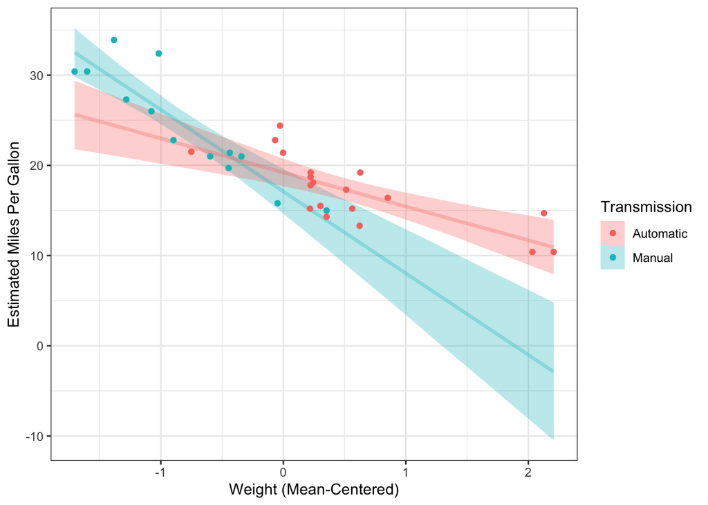

```r
# define grid of values to predict for
pred_grid = expand.grid(wt.c = seq(from = min(df$wt.c), to = max(df$wt.c), length.out = 20),
                        am = c(1,0))


# make predictions from model 1 (dummy coded)
model_preds = add_fitted_draws(model = m1, newdata = pred_grid)

# better labels for transmission
model_preds$`Transmission` = dplyr::recode(model_preds$am, '1'='Manual', '0'='Automatic')
df$`Transmission` = dplyr::recode(df$am, '1'='Manual', '0'='Automatic')

ggplot(model_preds, mapping = aes(x = wt.c, y = .value, color = `Transmission`, fill = `Transmission`)) +
  tidybayes::stat_lineribbon(.width = c(.95), alpha = .3) +
  geom_point(data = df, mapping = aes(x = wt.c, y = mpg, color = `Transmission`)) +
  theme_bw() +
  labs(x = 'Weight (Mean-Centered)', y = 'Estimated Miles Per Gallon')
```

Interestingly, we can see some strange consequences of our interaction model here – it is estimating that a manual transmission car as heavy as the heaviest automatic cars would have less than 0 miles per gallon. Part of this is because the manual transmission cars here are tending to be much lighter than the automatic ones. How might these considerations change how we interpret our model and interaction?

# Bonus

Try steps 3-6 again, but instead of using weight (`wt`) and transmission type (`am`) as predictors, use *2 categorical predictors* for your model: `am` and `cyl`. Note that `cyl` has 3 levels – 4, 6, or 8 cylinders.

How would you set up your variables for this model, interpret your parameters, and plot your model’s predicted estimates?

```r
# convert cyl to factor
df$cyl.f= as.factor(df$cyl)

# run model
m_bonus = rstanarm::stan_glm(data=df, mpg ~ am*cyl.f)
```

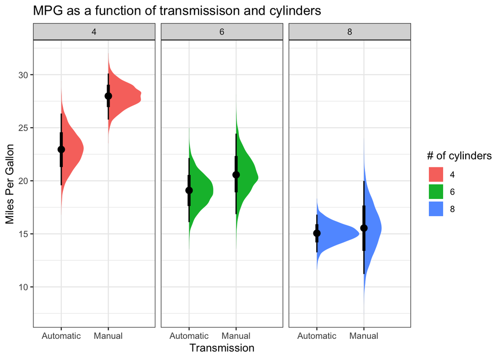

```r
# define grid of values to predict for
bonus_pred_grid = expand.grid(cyl.f = unique(df$cyl.f), am = c(1,0))

# make predictions from model
bonus_model_preds = add_fitted_draws(model = m_bonus, newdata = bonus_pred_grid)

# better labels for transmission
bonus_model_preds$`Transmission` = dplyr::recode(bonus_model_preds$am, '1'='Manual', '0'='Automatic')

ggplot(bonus_model_preds, mapping = aes(x = `Transmission`, y = .value, fill= cyl.f)) +
  tidybayes::stat_halfeye() +
  facet_grid(~cyl.f) +
  theme_bw() +
  labs(y = 'Miles Per Gallon', title = 'MPG as a function of transmissison and cylinders', fill = '# of cylinders')
```